# Population Health and Economic Impacts of Storm Events

Simon Cox

03 Nov 2019

## Synopsis

The following document provides an analysis of storm data from the US National Oceanic and Atmospheric Administration’s storm database, and its impact on human population health and the economy.

In summary the most significant types of storm events are:

- tornado (for human fatalities / injuries)
- flood (for property damage)
- drought (for crop damage).

The results show quite strongly that tornadoes are the most significant type of storm event when it comes to population health, causing the most human injuries and fatalities. However it is interesting to note that the most damaging types of storm events cross a range of conditions including wind-related (tornadoes, TSTM Wind), heat-related (excessive heat and heat), water-related (flood and flash flood) and other types of events (e.g. lightning and ice storm).

With regards to the economic impacts of storm events, 5 of the top 6 types of storm events causing property damage are all water-related (flood, hurricane/typhoon, storm surge, flash flood, hail), with tornadoes another major contributor.

However when it comes to the types of events that cause the most signficant crop damage we see that drought is by far the most significant, along with flood, river flood, ice storm, hail and hurricane / typhoon. Interestingly, tornadoes are not a big culprit for causing crop damage, sitting at number 17 on the list. This is possibly due to the fact that farmers choose not to farm in areas that are susceptible to tornado activity.

## Data Processing

The raw data is taken from the U.S. National Oceanic and Atmospheric Administration’s (NOAA) storm database, available [here](https://d396qusza40orc.cloudfront.net/repdata%2Fdata%2FStormData.csv.bz2). This data is compressed using the bzip2 algorithm, and so can be read directly into R using the standard read.csv function. The code used is shown below:

```r
# download file to ./data directory if it doesn't already exist
if (!file.exists("data")) {
    dir.create("data")
}

if (!file.exists("./data/storm_data.csv.bz2")) {
    fileURL <- "https://d396qusza40orc.cloudfront.net/repdata%2Fdata%2FStormData.csv.bz2"
    download.file(fileURL, destfile = "./data/storm_data.csv.bz2")
}

# load data into dataframe
storm_raw <- read.csv("./data/storm_data.csv.bz2",stringsAsFactors = FALSE)
```

### Data Transformations

An initial analysis of the data showed that there are a small number of columns of interest in order to understand the impact of storm events on population health:

- EVTYPE - which defines the storm event type
- FATALITIES - the number of human fatalities attributable to the storm event
- INJURIES - the number of human injuries attributable to the storm event

Additionally there are a small number of columns of interest in order to understand the economic impact of storm events:

- EVTYPE - which defines the storm event type
- PROPDMG - a number providing a representation of the cost of the property damage
- PROPEXP - a value that defines the multiplication factor against PROPDMG to get the value of the damage
- CROPDMG - a number providing a representation of the cost of the crop damage
- CROPEXP - a value that defines the multiplication factor against CROPDMG to get the value of the damage

The actual value of property / crop damage is not provided in the data. Therefore some transformation is required. A very helpful individual (David Song) left a comment on the project discussion board which provided a decoder for the PROPEXP and CROPEXP fields at this [link](https://github.com/dsong99/Reproducible-Proj-2/blob/master/storm_exp_code.csv).  
Using this decoder the true value of the damage to property and crops can be calculated in R:

```r
# reduce data to information of interest
storm <- storm_raw %>%
    select(EVTYPE,
           FATALITIES,
           INJURIES,
           PROPDMG,
           PROPDMGEXP,
           CROPDMG,
           CROPDMGEXP)

# create multiplier for exponent data
mult <- data.frame(exp = c("","-","?","+",0:8,"B","h","H","k","K","m","M")
                   , MULT = c(0,0,0,rep(1,10),1000000000,100,100,1000,1000,1000000,1000000))

# merge multiplier values into storm dataframe for crop damage and property damage
storm <- merge(storm,mult,by.x = "PROPDMGEXP", by.y = "exp")
storm <- storm %>% rename(PROPDMGMULT = MULT)
storm <- merge(storm,mult,by.x = "CROPDMGEXP", by.y = "exp")
storm <- storm %>% rename(CROPDMGMULT = MULT)

# create new columns for value of property damage and crop damage
storm <- storm %>%
    mutate(PROPDMGVAL = PROPDMG * PROPDMGMULT) %>%
    mutate(CROPDMGVAL = CROPDMG * CROPDMGMULT) %>%
    select(EVTYPE,
           FATALITIES,
           INJURIES,
           PROPDMGVAL,
           CROPDMGVAL)

# count the number of unique Event Types
unique_evtype <- length(unique(storm$EVTYPE))
```

## Data Analysis - Event Types

It is important to understand the data contained in the Event Type field of the dataset, in order to work out if any transformation is required. The documentation for the dataset suggests that there are around 40 unique event types that should have been logged in the database, so we should expect to see this in the actual data.  
A quick calculation shows that there are **985** unique values in the event type field, which is significantly more than expected most likely due to human input of character strings into the database rather than provision of a categorical dropdown input.  
Therefore some further analysis of this field is required - specifically are there a number of event types that have been commonly used and a small number that have only been used relatively rarely?  
The top 100 event types were determined and are output below:

```r
top_100 <- as.data.frame(storm %>%
                             group_by(EVTYPE) %>%
                             summarise(nbr = n()) %>%
                             top_n(100,nbr) %>%
                             arrange(desc(nbr)))
names(top_100) <- c("Event Type","Number of Events")
kable(top_100)
```

| Event Type | Number of Events |
| --- | --- |
| HAIL | 288661 |
| TSTM WIND | 219940 |
| THUNDERSTORM WIND | 82563 |
| TORNADO | 60652 |
| FLASH FLOOD | 54277 |
| FLOOD | 25326 |
| THUNDERSTORM WINDS | 20843 |
| HIGH WIND | 20212 |
| LIGHTNING | 15754 |
| HEAVY SNOW | 15708 |
| HEAVY RAIN | 11723 |
| WINTER STORM | 11433 |
| WINTER WEATHER | 7026 |
| FUNNEL CLOUD | 6839 |
| MARINE TSTM WIND | 6175 |
| MARINE THUNDERSTORM WIND | 5812 |
| WATERSPOUT | 3796 |
| STRONG WIND | 3566 |
| URBAN/SML STREAM FLD | 3392 |
| WILDFIRE | 2761 |
| BLIZZARD | 2719 |
| DROUGHT | 2488 |
| ICE STORM | 2006 |
| EXCESSIVE HEAT | 1678 |
| HIGH WINDS | 1533 |
| WILD/FOREST FIRE | 1457 |
| FROST/FREEZE | 1342 |
| DENSE FOG | 1293 |
| WINTER WEATHER/MIX | 1104 |
| TSTM WIND/HAIL | 1028 |

[output cut: 70 more lines]

This shows us that out of the total number of unique event types, only 69 have more than 100 entries in the dataset.  
Ideally we’d run a detailed data cleanse activity to try and fit all of the unique event types into the standard 40 event types suggested by the dataset documentation but time constraints prevent us from doing so. Therefore our analysis will make use of the event types as entered directly into the database, recognising that this is not ideal.

## Results

### Population Health Impacts

The health impacts are described by 2 fields - the number of injuries and the number of fatalities, and we can look at the storm events that impact on these in aggregate.

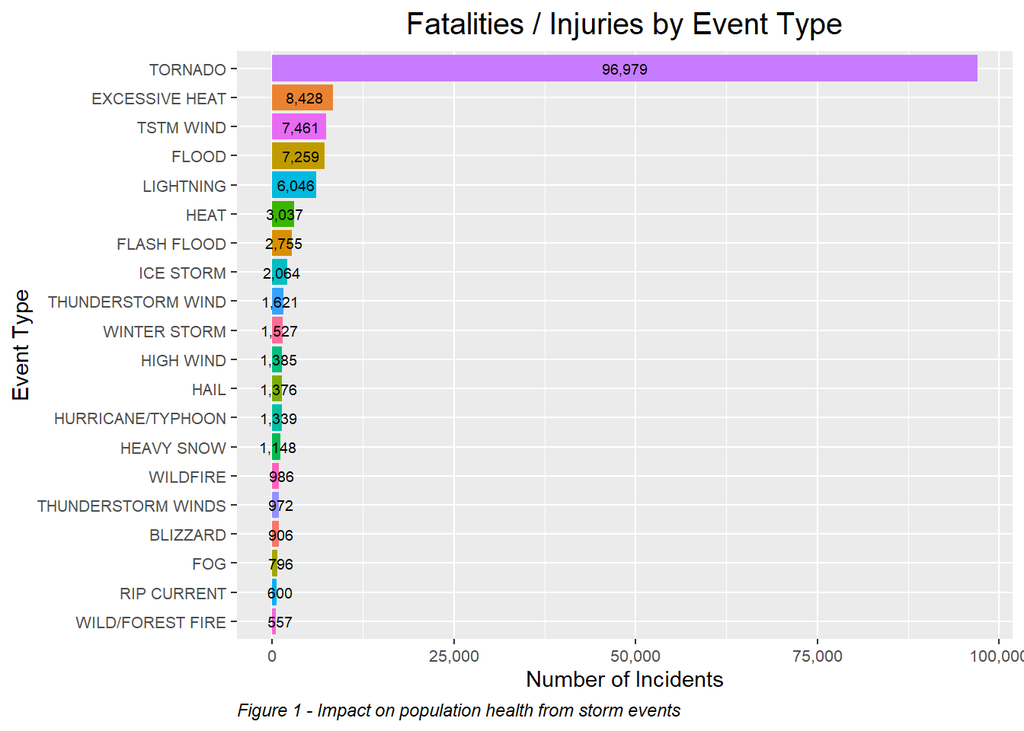

```r
by_event <- storm %>%
    mutate(INCIDENTS = INJURIES + FATALITIES) %>%
    group_by(EVTYPE)
incidents <- by_event %>%
    summarise(Total_Incidents = sum(INCIDENTS)) %>%
    arrange(desc(Total_Incidents)) %>%
    top_n(20,Total_Incidents)

g <- ggplot(data = incidents, aes(x = EVTYPE
                                 , y = Total_Incidents
                                 , fill=EVTYPE
                                 , label = Total_Incidents)) +
    geom_bar(stat="identity"
             , aes(reorder(EVTYPE,Total_Incidents),Total_Incidents)) +
    geom_text(size = 2.5
              , aes(label = format(Total_Incidents, big.mark = ","))
              , position = position_stack(vjust = 0.5, reverse = FALSE)) +
    scale_y_continuous(labels = comma) +
    coord_flip() +
    labs(title = "Fatalities / Injuries by Event Type"
         , caption = "Figure 1 - Impact on population health from storm events"
         , y = "Number of Incidents"
         , x = "Event Type") +
    theme(legend.position = ""
          , axis.text = element_text(size = 8)
          , plot.caption = element_text(hjust = 0,face = "italic")
          , plot.title = element_text(hjust = 0.5, size = 15))

print(g)
```

The chart shows quite conclusively that by far the most detrimental storm event to the health of the population is the tornado. A list of the most notable types of storm event that cause significant injuries and fatalities is below:

1. Tornado
2. Excessive Heat
3. TSTM Wind
4. Flood
5. Lightning

### Economic Impacts

The economic impacts are described by 2 fields - the value of property damage and the value of crop damage, and we can look at the storm events that impact on each of these in turn.

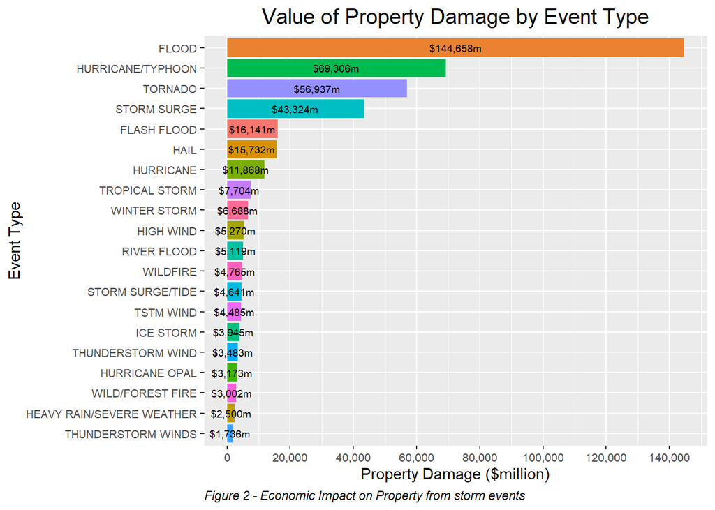

```r
usd <- dollar_format(largest_with_cents = 0, suffix = "m")
propdmg <- by_event %>%
    mutate(Property_Damage_m = PROPDMGVAL / 1000000) %>%
    summarise(Property_Damage = sum(Property_Damage_m)) %>%
    arrange(desc(Property_Damage)) %>%
    top_n(20,Property_Damage)

g <- ggplot(data = propdmg, aes(x = EVTYPE
                                 , y = Property_Damage
                                 , fill=EVTYPE
                                 , label = Property_Damage)) +
    geom_bar(stat="identity"
             , position = "dodge"
             , aes(reorder(EVTYPE,Property_Damage),Property_Damage)) +
    geom_text(size = 2.5
              , position = position_stack(vjust = 0.5)
              , aes(label = usd(Property_Damage))) +
    scale_y_continuous(breaks = c(seq(0,140000,20000)), labels = comma) +
    coord_flip() +
    labs(title = "Value of Property Damage by Event Type"
         , caption = "Figure 2 - Economic Impact on Property from storm events"
         , y = "Property Damage ($million)"
         , x = "Event Type") +
    theme(legend.position = ""
          , axis.text = element_text(size = 8)
          , plot.caption = element_text(hjust = 0, face = "italic")
          , plot.title = element_text(hjust = 0.5, size = 15))

print(g)
```

Figure 2 shows that with the exception of tornadoes, water-related events cause the most damage to property, with the most significant types of storm events being:

1. Flood
2. Hurricane / Typhoon
3. Tornado
4. Storm Surge
5. Flash Flood

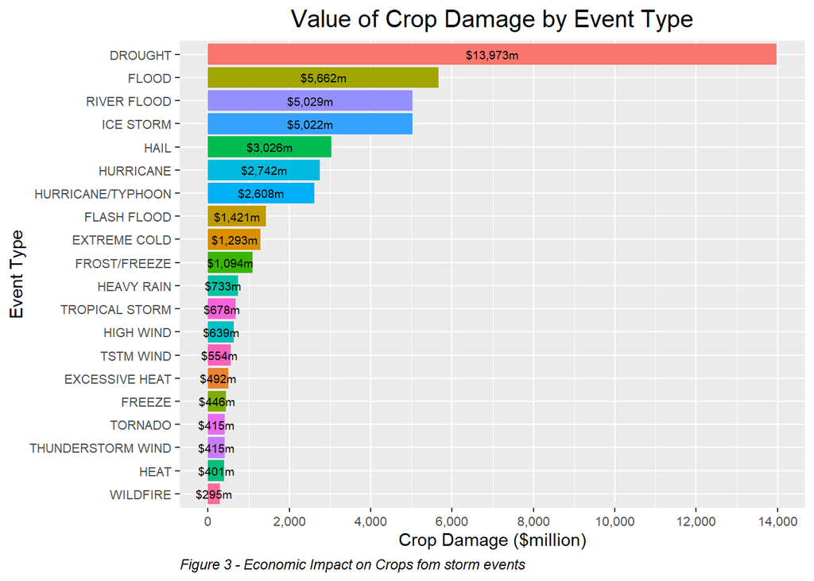

```r
usd <- dollar_format(largest_with_cents = 0, suffix = "m")
cropdmg <- by_event %>%
    mutate(Crop_Damage_m = CROPDMGVAL / 1000000) %>%
    summarise(Crop_Damage = sum(Crop_Damage_m)) %>%
    arrange(desc(Crop_Damage)) %>%
    top_n(20,Crop_Damage)

g <- ggplot(data = cropdmg, aes(x = EVTYPE
                                 , y = Crop_Damage
                                 , fill=EVTYPE
                                 , label = Crop_Damage)) +
    geom_bar(stat="identity"
             , position = "dodge"
             , aes(reorder(EVTYPE,Crop_Damage),Crop_Damage)) +
    geom_text(size = 2.5
              , position = position_stack(vjust = 0.5)
              , aes(label = usd(Crop_Damage))) +
    scale_y_continuous(breaks = c(seq(0,14000,2000)), labels = comma) +
    coord_flip() +
    labs(title = "Value of Crop Damage by Event Type"
         , caption = "Figure 3 - Economic Impact on Crops fom storm events"
         , y = "Crop Damage ($million)"
         , x = "Event Type") +
    theme(legend.position = ""
          , axis.text = element_text(size = 8)
          , plot.caption = element_text(hjust = 0, face = "italic")
          , plot.title = element_text(hjust = 0.5, size = 15))

print(g)
```

1. Drought
2. Flood
3. River Flood
4. Ice Storm
5. Hail

Figures 2 and 3 show that the total value of property damage is much higher than the total value of crop damage, by about a factor of 10.